# National Institute of Technology Rourkela, Odisha, India, 769008

## Department of Computer Science Engineering

### Laborotary-2

**(Data Science Laborotary)**

```python
#Name : Alen Scaria
#Roll No. : 121CS0237
#Lab No. : 2
```

```python
import numpy as np #Numpy stands for Numerical Python. used for numerical Operations
import pandas as pd #Pandas is used for DataFrame/Database Operations
import warnings
warnings.filterwarnings("ignore")

pd.set_option("display.precision", 2)
```

Read the telecom_churn csv file.

```python
telecom=pd.read_csv("telecom_churn.csv")
```

Show the first 10 rows of the dataset

```python
telecom.head(10)
```

|  | State | Account length | Area code | International plan | Voice mail plan | Number vmail messages | Total day minutes | Total day calls | Total day charge | Total eve minutes | Total eve calls | Total eve charge | Total night minutes | Total night calls | Total night charge | Total intl minutes | Total intl calls | Total intl charge | Customer service calls | Churn |
| --- | --- | --- | --- | --- | --- | --- | --- | --- | --- | --- | --- | --- | --- | --- | --- | --- | --- | --- | --- | --- |
| 0 | KS | 128 | 415 | No | Yes | 25.0 | 265.1 | 110 | 45.07 | 197.4 | 99 | 16.78 | 244.7 | 91 | 11.01 | 10.0 | 3 | 2.70 | 1 | False |
| 1 | OH | 107 | 415 | No | Yes | 26.0 | 161.6 | 123 | 27.47 | 195.5 | 103 | 16.62 | 254.4 | 103 | 11.45 | 13.7 | 3 | 3.70 | 1 | False |
| 2 | NJ | 137 | 415 | No | No | NaN | 243.4 | 114 | 41.38 | 121.2 | 110 | 10.30 | 162.6 | 104 | 7.32 | 12.2 | 5 | 3.29 | 0 | False |
| 3 | OH | 84 | 408 | Yes | No | NaN | 299.4 | 71 | 50.90 | 61.9 | 88 | 5.26 | 196.9 | 89 | 8.86 | 6.6 | 7 | 1.78 | 2 | False |
| 4 | OK | 75 | 415 | Yes | No | 0.0 | 166.7 | 113 | 28.34 | 148.3 | 122 | 12.61 | 186.9 | 121 | 8.41 | 10.1 | 3 | 2.73 | 3 | False |
| 5 | AL | 118 | 510 | Yes | No | 0.0 | NaN | 98 | 37.98 | 220.6 | 101 | 18.75 | 203.9 | 118 | 9.18 | 6.3 | 6 | 1.70 | 0 | False |
| 6 | MA | 121 | 510 | No | Yes | 24.0 | 218.2 | 88 | 37.09 | 348.5 | 108 | 29.62 | 212.6 | 118 | 9.57 | 7.5 | 7 | 2.03 | 3 | False |
| 7 | MO | 147 | 415 | Yes | No | 0.0 | 157.0 | 79 | 26.69 | 103.1 | 94 | 8.76 | 211.8 | 96 | 9.53 | 7.1 | 6 | 1.92 | 0 | False |
| 8 | LA | 117 | 408 | No | No | 0.0 | 184.5 | 97 | 31.37 | 351.6 | 80 | 29.89 | 215.8 | 90 | 9.71 | 8.7 | 4 | 2.35 | 1 | False |
| 9 | WV | 141 | 415 | Yes | Yes | 37.0 | 258.6 | 84 | 43.96 | 222.0 | 111 | 18.87 | 326.4 | 97 | 14.69 | 11.2 | 5 | 3.02 | 0 | False |

Show the last 10 rows of the dataset

```python
telecom.tail(10)
```

|  | State | Account length | Area code | International plan | Voice mail plan | Number vmail messages | Total day minutes | Total day calls | Total day charge | Total eve minutes | Total eve calls | Total eve charge | Total night minutes | Total night calls | Total night charge | Total intl minutes | Total intl calls | Total intl charge | Customer service calls | Churn |
| --- | --- | --- | --- | --- | --- | --- | --- | --- | --- | --- | --- | --- | --- | --- | --- | --- | --- | --- | --- | --- |
| 3323 | IN | 117 | 415 | No | No | 0.0 | 118.4 | 126 | 20.13 | 249.3 | 97 | 21.19 | 227.0 | 56 | 10.22 | 13.6 | 3 | 3.67 | 5 | True |
| 3324 | WV | 159 | 415 | No | No | 0.0 | 169.8 | 114 | 28.87 | 197.7 | 105 | 16.80 | 193.7 | 82 | 8.72 | 11.6 | 4 | 3.13 | 1 | False |
| 3325 | OH | 78 | 408 | No | No | 0.0 | 193.4 | 99 | 32.88 | 116.9 | 88 | 9.94 | 243.3 | 109 | 10.95 | 9.3 | 4 | 2.51 | 2 | False |
| 3326 | OH | 96 | 415 | No | No | 0.0 | 106.6 | 128 | 18.12 | 284.8 | 87 | 24.21 | 178.9 | 92 | 8.05 | 14.9 | 7 | 4.02 | 1 | False |
| 3327 | SC | 79 | 415 | No | No | 0.0 | 134.7 | 98 | 22.90 | 189.7 | 68 | 16.12 | 221.4 | 128 | 9.96 | 11.8 | 5 | 3.19 | 2 | False |
| 3328 | AZ | 192 | 415 | No | Yes | 36.0 | 156.2 | 77 | 26.55 | 215.5 | 126 | 18.32 | 279.1 | 83 | 12.56 | 9.9 | 6 | 2.67 | 2 | False |
| 3329 | WV | 68 | 415 | No | No | 0.0 | 231.1 | 57 | 39.29 | 153.4 | 55 | 13.04 | 191.3 | 123 | 8.61 | 9.6 | 4 | 2.59 | 3 | False |
| 3330 | RI | 28 | 510 | No | No | 0.0 | 180.8 | 109 | 30.74 | 288.8 | 58 | 24.55 | 191.9 | 91 | 8.64 | 14.1 | 6 | 3.81 | 2 | False |
| 3331 | CT | 184 | 510 | Yes | No | 0.0 | 213.8 | 105 | 36.35 | 159.6 | 84 | 13.57 | 139.2 | 137 | 6.26 | 5.0 | 10 | 1.35 | 2 | False |
| 3332 | TN | 74 | 415 | No | Yes | 25.0 | 234.4 | 113 | 39.85 | 265.9 | 82 | 22.60 | 241.4 | 77 | 10.86 | 13.7 | 4 | 3.70 | 0 | False |

Show the dimensions (No. of rows and coulmns) of the dataset

```python
print(f'Rows : {telecom.shape[0]} & Columns : {telecom.shape[1]}'  )
```

```
Rows : 3333 & Columns : 20
```

Print all the column names of the dataset

```python
telecom.columns
```

```
Index(['State', 'Account length', 'Area code', 'International plan',
       'Voice mail plan', 'Number vmail messages', 'Total day minutes',
       'Total day calls', 'Total day charge', 'Total eve minutes',
       'Total eve calls', 'Total eve charge', 'Total night minutes',
       'Total night calls', 'Total night charge', 'Total intl minutes',
       'Total intl calls', 'Total intl charge', 'Customer service calls',
       'Churn'],
      dtype='object')
```

Print general information of the dataset like column, and datatype.

```python
telecom.info()
```

```
<class 'pandas.core.frame.DataFrame'>
RangeIndex: 3333 entries, 0 to 3332
Data columns (total 20 columns):
 #   Column                  Non-Null Count  Dtype
---  ------                  --------------  -----
 0   State                   3333 non-null   object
 1   Account length          3333 non-null   int64
 2   Area code               3333 non-null   int64
 3   International plan      3333 non-null   object
 4   Voice mail plan         3333 non-null   object
 5   Number vmail messages   3328 non-null   float64
 6   Total day minutes       3329 non-null   float64
 7   Total day calls         3333 non-null   int64
 8   Total day charge        3333 non-null   float64
 9   Total eve minutes       3333 non-null   float64
 10  Total eve calls         3333 non-null   int64
 11  Total eve charge        3333 non-null   float64
 12  Total night minutes     3333 non-null   float64
 13  Total night calls       3333 non-null   int64
 14  Total night charge      3333 non-null   float64
 15  Total intl minutes      3333 non-null   float64
 16  Total intl calls        3333 non-null   int64
 17  Total intl charge       3333 non-null   float64
 18  Customer service calls  3333 non-null   int64
 19  Churn                   3333 non-null   bool
dtypes: bool(1), float64(9), int64(7), object(3)
memory usage: 498.1+ KB
```

After getting the datatype of every feature, you can see that there is a feature "**churn**" having Dtype as **bool**. Change that Dtype to **int64**.

```python
df = pd.DataFrame(telecom)
df['Churn'] = df['Churn'].astype('int64')
print(df.dtypes)
```

```
State                      object
Account length              int64
Area code                   int64
International plan         object
Voice mail plan            object
Number vmail messages     float64
Total day minutes         float64
Total day calls             int64
Total day charge          float64
Total eve minutes         float64
Total eve calls             int64
Total eve charge          float64
Total night minutes       float64
Total night calls           int64
Total night charge        float64
Total intl minutes        float64
Total intl calls            int64
Total intl charge         float64
Customer service calls      int64
Churn                       int64
dtype: object
```

Which method shows basic statistical characteristics of each numerical feature (`int64` and `float64` types): number of non-missing values, mean, standard deviation, range, median, 0.25 and 0.75 quartiles.

```python
df.describe()
```

|  | Account length | Area code | Number vmail messages | Total day minutes | Total day calls | Total day charge | Total eve minutes | Total eve calls | Total eve charge | Total night minutes | Total night calls | Total night charge | Total intl minutes | Total intl calls | Total intl charge | Customer service calls | Churn |
| --- | --- | --- | --- | --- | --- | --- | --- | --- | --- | --- | --- | --- | --- | --- | --- | --- | --- |
| count | 3333.00 | 3333.00 | 3328.00 | 3329.00 | 3333.00 | 3333.00 | 3333.00 | 3333.00 | 3333.00 | 3333.00 | 3333.00 | 3333.00 | 3333.00 | 3333.00 | 3333.00 | 3333.00 | 3333.00 |
| mean | 101.06 | 437.18 | 8.11 | 179.78 | 100.44 | 30.56 | 200.98 | 100.11 | 17.08 | 200.87 | 100.11 | 9.04 | 10.24 | 4.48 | 2.76 | 1.56 | 0.14 |
| std | 39.82 | 42.37 | 13.70 | 54.48 | 20.07 | 9.26 | 50.71 | 19.92 | 4.31 | 50.57 | 19.57 | 2.28 | 2.79 | 2.46 | 0.75 | 1.32 | 0.35 |
| min | 1.00 | 408.00 | 0.00 | 0.00 | 0.00 | 0.00 | 0.00 | 0.00 | 0.00 | 23.20 | 33.00 | 1.04 | 0.00 | 0.00 | 0.00 | 0.00 | 0.00 |
| 25% | 74.00 | 408.00 | 0.00 | 143.70 | 87.00 | 24.43 | 166.60 | 87.00 | 14.16 | 167.00 | 87.00 | 7.52 | 8.50 | 3.00 | 2.30 | 1.00 | 0.00 |
| 50% | 101.00 | 415.00 | 0.00 | 179.40 | 101.00 | 30.50 | 201.40 | 100.00 | 17.12 | 201.20 | 100.00 | 9.05 | 10.30 | 4.00 | 2.78 | 1.00 | 0.00 |
| 75% | 127.00 | 510.00 | 20.00 | 216.40 | 114.00 | 36.79 | 235.30 | 114.00 | 20.00 | 235.30 | 113.00 | 10.59 | 12.10 | 6.00 | 3.27 | 2.00 | 0.00 |
| max | 243.00 | 510.00 | 51.00 | 350.80 | 165.00 | 59.64 | 363.70 | 170.00 | 30.91 | 395.00 | 175.00 | 17.77 | 20.00 | 20.00 | 5.40 | 9.00 | 1.00 |

How to show the basic statistics for categorical (type `object`) and boolean (type `bool`) features?

```python
df.describe(include=["object","bool"])
```

|  | State | International plan | Voice mail plan |
| --- | --- | --- | --- |
| count | 3333 | 3333 | 3333 |
| unique | 51 | 2 | 2 |
| top | WV | No | No |
| freq | 106 | 3010 | 2411 |

## Check for Missing Values

How to check for missing values in each column?

```python
missing_values_per_column = telecom.isnull().sum()
print(missing_values_per_column)
```

```
State                     0
Account length            0
Area code                 0
International plan        0
Voice mail plan           0
Number vmail messages     5
Total day minutes         4
Total day calls           0
Total day charge          0
Total eve minutes         0
Total eve calls           0
Total eve charge          0
Total night minutes       0
Total night calls         0
Total night charge        0
Total intl minutes        0
Total intl calls          0
Total intl charge         0
Customer service calls    0
Churn                     0
dtype: int64
```

## Sorting

How to sort a dataFrame using one of the variables (i.e columns) in ascending order and also in descending order?

```python
#descending order
df.sort_values(by='Area code', ascending=False, inplace=True)
df.head()
```

|  | State | Account length | Area code | International plan | Voice mail plan | Number vmail messages | Total day minutes | Total day calls | Total day charge | Total eve minutes | Total eve calls | Total eve charge | Total night minutes | Total night calls | Total night charge | Total intl minutes | Total intl calls | Total intl charge | Customer service calls | Churn |
| --- | --- | --- | --- | --- | --- | --- | --- | --- | --- | --- | --- | --- | --- | --- | --- | --- | --- | --- | --- | --- |
| 835 | GA | 27 | 510 | No | No | 0.0 | 72.7 | 75 | 12.36 | 208.6 | 117 | 17.73 | 65.8 | 71 | 2.96 | 9.9 | 3 | 2.67 | 1 | 0 |
| 2392 | WY | 90 | 510 | No | No | 0.0 | 125.4 | 158 | 21.32 | 269.1 | 83 | 22.87 | 238.6 | 103 | 10.74 | 11.0 | 7 | 2.97 | 1 | 0 |
| 2383 | ID | 68 | 510 | No | Yes | 30.0 | 122.9 | 93 | 20.89 | 233.5 | 91 | 19.85 | 199.5 | 144 | 8.98 | 9.6 | 2 | 2.59 | 2 | 0 |
| 2384 | CT | 40 | 510 | Yes | No | 0.0 | 220.8 | 100 | 37.54 | 265.7 | 106 | 22.58 | 212.8 | 94 | 9.58 | 6.4 | 3 | 1.73 | 0 | 0 |
| 2388 | SC | 161 | 510 | No | No | 0.0 | 297.9 | 141 | 50.64 | 238.1 | 107 | 20.24 | 240.5 | 93 | 10.82 | 8.9 | 5 | 2.40 | 1 | 1 |

```python
#ascending order
df.sort_values(by='Area code', ascending=True, inplace=True)
df.head()
```

|  | State | Account length | Area code | International plan | Voice mail plan | Number vmail messages | Total day minutes | Total day calls | Total day charge | Total eve minutes | Total eve calls | Total eve charge | Total night minutes | Total night calls | Total night charge | Total intl minutes | Total intl calls | Total intl charge | Customer service calls | Churn |
| --- | --- | --- | --- | --- | --- | --- | --- | --- | --- | --- | --- | --- | --- | --- | --- | --- | --- | --- | --- | --- |
| 2502 | DC | 115 | 408 | No | No | 0.0 | 178.7 | 114 | 30.38 | 271.0 | 96 | 23.04 | 245.9 | 94 | 11.07 | 16.4 | 5 | 4.43 | 2 | 0 |
| 267 | NH | 119 | 408 | No | No | 0.0 | 138.3 | 89 | 23.51 | 170.5 | 78 | 14.49 | 263.9 | 98 | 11.88 | 13.5 | 6 | 3.65 | 3 | 0 |
| 269 | MA | 118 | 408 | Yes | No | 0.0 | 160.0 | 123 | 27.20 | 175.4 | 96 | 14.91 | 184.8 | 99 | 8.32 | 9.9 | 3 | 2.67 | 2 | 0 |
| 1790 | KY | 125 | 408 | No | No | 0.0 | 191.6 | 115 | 32.57 | 205.6 | 108 | 17.48 | 210.2 | 123 | 9.46 | 9.2 | 3 | 2.48 | 2 | 0 |
| 3048 | AL | 95 | 408 | No | No | 0.0 | 190.2 | 119 | 32.33 | 157.1 | 70 | 13.35 | 181.5 | 120 | 8.17 | 14.0 | 6 | 3.78 | 0 | 0 |

How to sort a dataFrame using multiple variables (i.e columns) in ascending order and also in descending order?

```python
df = df.sort_values(['State', 'Area code'], ascending=True)
df.head()
```

|  | State | Account length | Area code | International plan | Voice mail plan | Number vmail messages | Total day minutes | Total day calls | Total day charge | Total eve minutes | Total eve calls | Total eve charge | Total night minutes | Total night calls | Total night charge | Total intl minutes | Total intl calls | Total intl charge | Customer service calls | Churn |
| --- | --- | --- | --- | --- | --- | --- | --- | --- | --- | --- | --- | --- | --- | --- | --- | --- | --- | --- | --- | --- |
| 3236 | AK | 121 | 408 | No | Yes | 34.0 | 245.0 | 95 | 41.65 | 216.9 | 66 | 18.44 | 112.4 | 125 | 5.06 | 7.5 | 8 | 2.03 | 0 | 0 |
| 339 | AK | 78 | 408 | No | No | 0.0 | 225.1 | 67 | 38.27 | 199.2 | 127 | 16.93 | 175.5 | 102 | 7.90 | 14.6 | 2 | 3.94 | 0 | 0 |
| 1682 | AK | 96 | 408 | No | Yes | 29.0 | 150.0 | 91 | 25.50 | 159.4 | 75 | 13.55 | 228.1 | 55 | 10.26 | 8.5 | 3 | 2.30 | 1 | 0 |
| 95 | AK | 104 | 408 | No | No | 0.0 | 278.4 | 106 | 47.33 | 81.0 | 113 | 6.89 | 163.2 | 137 | 7.34 | 9.8 | 5 | 2.65 | 1 | 0 |
| 36 | AK | 36 | 408 | No | Yes | 30.0 | NaN | 128 | 24.87 | 162.5 | 80 | 13.81 | 129.3 | 109 | 5.82 | 14.5 | 6 | 3.92 | 0 | 0 |

```python
df = df.sort_values(['State', 'Area code'], ascending=False)
df.head()
```

|  | State | Account length | Area code | International plan | Voice mail plan | Number vmail messages | Total day minutes | Total day calls | Total day charge | Total eve minutes | Total eve calls | Total eve charge | Total night minutes | Total night calls | Total night charge | Total intl minutes | Total intl calls | Total intl charge | Customer service calls | Churn |
| --- | --- | --- | --- | --- | --- | --- | --- | --- | --- | --- | --- | --- | --- | --- | --- | --- | --- | --- | --- | --- |
| 730 | WY | 94 | 510 | No | No | 0.0 | 271.2 | 105 | 46.10 | 202.6 | 105 | 17.22 | 221.6 | 51 | 9.97 | 11.5 | 3 | 3.11 | 3 | 1 |
| 1832 | WY | 68 | 510 | No | No | 0.0 | 195.4 | 116 | 33.22 | 212.1 | 101 | 18.03 | 138.4 | 134 | 6.23 | 15.1 | 11 | 4.08 | 1 | 0 |
| 1422 | WY | 107 | 510 | No | Yes | 31.0 | 160.3 | 45 | 27.25 | 221.5 | 70 | 18.83 | 261.6 | 109 | 11.77 | 5.6 | 1 | 1.51 | 1 | 0 |
| 1628 | WY | 131 | 510 | No | No | 0.0 | 110.9 | 74 | 18.85 | 115.6 | 90 | 9.83 | 190.5 | 114 | 8.57 | 15.8 | 9 | 4.27 | 1 | 0 |
| 1533 | WY | 127 | 510 | Yes | No | 0.0 | 242.2 | 102 | 41.17 | 226.1 | 80 | 19.22 | 252.0 | 96 | 11.34 | 13.9 | 5 | 3.75 | 2 | 1 |

## Indexing and retrieving data

What is the proportion of churned users in our dataframe?

```python
df["Churn"].mean()
```

```
0.14491449144914492
```

What are average values of numerical features for churned users?

```python
df[df["Churn"] == 1].select_dtypes(include="number").mean()
```

```
Account length            102.66
Area code                 437.82
Number vmail messages       5.12
Total day minutes         206.91
Total day calls           101.34
Total day charge           35.18
Total eve minutes         212.41
Total eve calls           100.56
Total eve charge           18.05
Total night minutes       205.23
Total night calls         100.40
Total night charge          9.24
Total intl minutes         10.70
Total intl calls            4.16
Total intl charge           2.89
Customer service calls      2.23
Churn                       1.00
dtype: float64
```

How much time (on average) do churned users spend on the phone during daytime?

```python
df[df["Churn"] == 1]["Total day minutes"].mean()
```

```
206.91407867494826
```

What is the maximum length of international calls among loyal users (`Churn == 0`) who do not have an international plan?

```python
df[(df["Churn"] == 0) & (df["International plan"] == "No")]["Total intl minutes"].max()
```

```
18.9
```

How to get the first or the last line of the data frame?

```python
(df.head(1)) #first line
# (df.tail(1)) # last line
```

|  | State | Account length | Area code | International plan | Voice mail plan | Number vmail messages | Total day minutes | Total day calls | Total day charge | Total eve minutes | Total eve calls | Total eve charge | Total night minutes | Total night calls | Total night charge | Total intl minutes | Total intl calls | Total intl charge | Customer service calls | Churn |
| --- | --- | --- | --- | --- | --- | --- | --- | --- | --- | --- | --- | --- | --- | --- | --- | --- | --- | --- | --- | --- |
| 730 | WY | 94 | 510 | No | No | 0.0 | 271.2 | 105 | 46.1 | 202.6 | 105 | 17.22 | 221.6 | 51 | 9.97 | 11.5 | 3 | 3.11 | 3 | 1 |

### Applying Functions to Cells, Columns and Rows

How can you apply a function to each column of a DataFrame to find the maximum value in each column?

```python
maxValues = df.max()
print(maxValues)
```

```
State                        WY
Account length              243
Area code                   510
International plan          Yes
Voice mail plan             Yes
Number vmail messages      51.0
Total day minutes         350.8
Total day calls             165
Total day charge          59.64
Total eve minutes         363.7
Total eve calls             170
Total eve charge          30.91
Total night minutes       395.0
Total night calls           175
Total night charge        17.77
Total intl minutes         20.0
Total intl calls             20
Total intl charge           5.4
Customer service calls        9
Churn                         1
dtype: object
```

How can you filter rows in a DataFrame to select all states that start with the letter "W"?

```python
df[df["State"].apply(lambda state: state[0] == "W")].head()
```

|  | State | Account length | Area code | International plan | Voice mail plan | Number vmail messages | Total day minutes | Total day calls | Total day charge | Total eve minutes | Total eve calls | Total eve charge | Total night minutes | Total night calls | Total night charge | Total intl minutes | Total intl calls | Total intl charge | Customer service calls | Churn |
| --- | --- | --- | --- | --- | --- | --- | --- | --- | --- | --- | --- | --- | --- | --- | --- | --- | --- | --- | --- | --- |
| 730 | WY | 94 | 510 | No | No | 0.0 | 271.2 | 105 | 46.10 | 202.6 | 105 | 17.22 | 221.6 | 51 | 9.97 | 11.5 | 3 | 3.11 | 3 | 1 |
| 1832 | WY | 68 | 510 | No | No | 0.0 | 195.4 | 116 | 33.22 | 212.1 | 101 | 18.03 | 138.4 | 134 | 6.23 | 15.1 | 11 | 4.08 | 1 | 0 |
| 1422 | WY | 107 | 510 | No | Yes | 31.0 | 160.3 | 45 | 27.25 | 221.5 | 70 | 18.83 | 261.6 | 109 | 11.77 | 5.6 | 1 | 1.51 | 1 | 0 |
| 1628 | WY | 131 | 510 | No | No | 0.0 | 110.9 | 74 | 18.85 | 115.6 | 90 | 9.83 | 190.5 | 114 | 8.57 | 15.8 | 9 | 4.27 | 1 | 0 |
| 1533 | WY | 127 | 510 | Yes | No | 0.0 | 242.2 | 102 | 41.17 | 226.1 | 80 | 19.22 | 252.0 | 96 | 11.34 | 13.9 | 5 | 3.75 | 2 | 1 |

How can you replace values in a DataFrame column, such as changing the values of "International plan" and "Voice mail plan" from "Yes" or "No" to True or False?

```python
d = {"No": False, "Yes": True}
df["International plan"] = df["International plan"].map(d)
df.head()
```

|  | State | Account length | Area code | International plan | Voice mail plan | Number vmail messages | Total day minutes | Total day calls | Total day charge | Total eve minutes | Total eve calls | Total eve charge | Total night minutes | Total night calls | Total night charge | Total intl minutes | Total intl calls | Total intl charge | Customer service calls | Churn |
| --- | --- | --- | --- | --- | --- | --- | --- | --- | --- | --- | --- | --- | --- | --- | --- | --- | --- | --- | --- | --- |
| 730 | WY | 94 | 510 | False | No | 0.0 | 271.2 | 105 | 46.10 | 202.6 | 105 | 17.22 | 221.6 | 51 | 9.97 | 11.5 | 3 | 3.11 | 3 | 1 |
| 1832 | WY | 68 | 510 | False | No | 0.0 | 195.4 | 116 | 33.22 | 212.1 | 101 | 18.03 | 138.4 | 134 | 6.23 | 15.1 | 11 | 4.08 | 1 | 0 |
| 1422 | WY | 107 | 510 | False | Yes | 31.0 | 160.3 | 45 | 27.25 | 221.5 | 70 | 18.83 | 261.6 | 109 | 11.77 | 5.6 | 1 | 1.51 | 1 | 0 |
| 1628 | WY | 131 | 510 | False | No | 0.0 | 110.9 | 74 | 18.85 | 115.6 | 90 | 9.83 | 190.5 | 114 | 8.57 | 15.8 | 9 | 4.27 | 1 | 0 |
| 1533 | WY | 127 | 510 | True | No | 0.0 | 242.2 | 102 | 41.17 | 226.1 | 80 | 19.22 | 252.0 | 96 | 11.34 | 13.9 | 5 | 3.75 | 2 | 1 |

### Grouping

In general, grouping data in Pandas works as follows:

```
df.groupby(by=grouping_columns)[columns_to_show].function()
```

1. First, the `groupby` method divides the `grouping_columns` by their values. They become a new index in the resulting dataframe.
2. Then, columns of interest are selected (`columns_to_show`). If `columns_to_show` is not included, all non groupby clauses will be included.
3. Finally, one or several functions are applied to the obtained groups per selected columns.

How can you group data by a specific column (e.g., "Churn") and then display statistical summaries (e.g., mean, standard deviation, etc.) for selected columns such as "Total day minutes," "Total eve minutes," and "Total night minutes"?

```python
columns_to_show = ["Total day minutes", "Total eve minutes", "Total night minutes"]
df.groupby(["Churn"])[columns_to_show].describe(percentiles=[])
```

| Churn | Total day minutes count | Total day minutes mean | Total day minutes std | Total day minutes min | Total day minutes 50% | Total day minutes max | Total eve minutes count | Total eve minutes mean | Total eve minutes std | Total eve minutes min | Total eve minutes 50% | Total eve minutes max | Total night minutes count | Total night minutes mean | Total night minutes std | Total night minutes min | Total night minutes 50% | Total night minutes max |
| --- | --- | --- | --- | --- | --- | --- | --- | --- | --- | --- | --- | --- | --- | --- | --- | --- | --- | --- |
| 0 | 2846.0 | 175.18 | 50.2 | 0.0 | 177.2 | 315.6 | 2850.0 | 199.04 | 50.29 | 0.0 | 199.6 | 361.8 | 2850.0 | 200.13 | 51.11 | 23.2 | 200.25 | 395.0 |
| 1 | 483.0 | 206.91 | 69.0 | 0.0 | 217.6 | 350.8 | 483.0 | 212.41 | 51.73 | 70.9 | 211.3 | 363.7 | 483.0 | 205.23 | 47.13 | 47.4 | 204.80 | 354.9 |

How can you group data by a specific column (e.g., "Churn") and then apply multiple aggregation functions (e.g., mean, standard deviation, min, max) to selected columns such as "Total day minutes," "Total eve minutes," and "Total night minutes"?

```python
columns_to_show = ["Total day minutes", "Total eve minutes", "Total night minutes"]

df.groupby(["Churn"])[columns_to_show].agg([np.mean, np.std, np.min, np.max])
```

| Churn | Total day minutes mean | Total day minutes std | Total day minutes min | Total day minutes max | Total eve minutes mean | Total eve minutes std | Total eve minutes min | Total eve minutes max | Total night minutes mean | Total night minutes std | Total night minutes min | Total night minutes max |
| --- | --- | --- | --- | --- | --- | --- | --- | --- | --- | --- | --- | --- |
| 0 | 175.18 | 50.2 | 0.0 | 315.6 | 199.04 | 50.29 | 0.0 | 361.8 | 200.13 | 51.11 | 23.2 | 395.0 |
| 1 | 206.91 | 69.0 | 0.0 | 350.8 | 212.41 | 51.73 | 70.9 | 363.7 | 205.23 | 47.13 | 47.4 | 354.9 |

### Summary tables

How can you create a contingency table to observe the distribution of data across two variables, such as "Churn" and "International plan"?

```python
pd.crosstab(df["Churn"], df["International plan"])
```

| International plan Churn | False | True |
| --- | --- | --- |
| 0 | 2664 | 186 |
| 1 | 346 | 137 |

How can you create a contingency table to observe the distribution of data across two variables, such as "Churn" and "Voice mail plan"?

```python
pd.crosstab(df["Churn"], df["Voice mail plan"], normalize=True)
```

| Voice mail plan Churn | No | Yes |
| --- | --- | --- |
| 0 | 0.60 | 0.25 |
| 1 | 0.12 | 0.02 |

How can you create a pivot table to calculate the average number of day, evening, and night calls grouped by "Area code"?

```python
df.pivot_table(
    ["Total day calls", "Total eve calls", "Total night calls"],
    ["Area code"],
    aggfunc="mean",
)
```

| Area code | Total day calls | Total eve calls | Total night calls |
| --- | --- | --- | --- |
| 408 | 100.50 | 99.79 | 99.04 |
| 415 | 100.58 | 100.50 | 100.40 |
| 510 | 100.10 | 99.67 | 100.60 |

### DataFrame transformations

How can you calculate the total number of calls ("Total day calls", "Total eve calls", "Total night calls", and "Total intl calls") for all users and add this information as a new column named "Total calls" to the DataFrame?

```python
total_calls = (
    df["Total day calls"]
    + df["Total eve calls"]
    + df["Total night calls"]
    + df["Total intl calls"]
)
df.insert(loc=len(df.columns), column="Total calls", value=total_calls)

df.head()
```

|  | State | Account length | Area code | International plan | Voice mail plan | Number vmail messages | Total day minutes | Total day calls | Total day charge | Total eve minutes | ... | Total eve charge | Total night minutes | Total night calls | Total night charge | Total intl minutes | Total intl calls | Total intl charge | Customer service calls | Churn | Total calls |
| --- | --- | --- | --- | --- | --- | --- | --- | --- | --- | --- | --- | --- | --- | --- | --- | --- | --- | --- | --- | --- | --- |
| 730 | WY | 94 | 510 | False | No | 0.0 | 271.2 | 105 | 46.10 | 202.6 | ... | 17.22 | 221.6 | 51 | 9.97 | 11.5 | 3 | 3.11 | 3 | 1 | 264 |
| 1832 | WY | 68 | 510 | False | No | 0.0 | 195.4 | 116 | 33.22 | 212.1 | ... | 18.03 | 138.4 | 134 | 6.23 | 15.1 | 11 | 4.08 | 1 | 0 | 362 |
| 1422 | WY | 107 | 510 | False | Yes | 31.0 | 160.3 | 45 | 27.25 | 221.5 | ... | 18.83 | 261.6 | 109 | 11.77 | 5.6 | 1 | 1.51 | 1 | 0 | 225 |
| 1628 | WY | 131 | 510 | False | No | 0.0 | 110.9 | 74 | 18.85 | 115.6 | ... | 9.83 | 190.5 | 114 | 8.57 | 15.8 | 9 | 4.27 | 1 | 0 | 287 |
| 1533 | WY | 127 | 510 | True | No | 0.0 | 242.2 | 102 | 41.17 | 226.1 | ... | 19.22 | 252.0 | 96 | 11.34 | 13.9 | 5 | 3.75 | 2 | 1 | 283 |

5 rows × 21 columns

How can you delete specific columns or rows from a DataFrame? **Note:** It should alters the current DataFrame and should not return a new one.

```python
# df.drop(["State", "Area code"], axis=1, inplace=True)
# df.head()
# and here’s how you can delete rows
df.drop([1, 2]).head()
```

[output not shown]

# Visualizing the Data

We'll do this using visual analysis with `matplotlib` and `Seaborn`.

```python
# some imports to set up plotting
import matplotlib.pyplot as plt
# !pip install seaborn
import seaborn as sns

# Graphics in retina format are more sharp and legible
%config InlineBackend.figure_format = 'retina'
```

How can you create a count plot to visualize the distribution of the "International plan" variable, with separate bars for each "Churn" category,

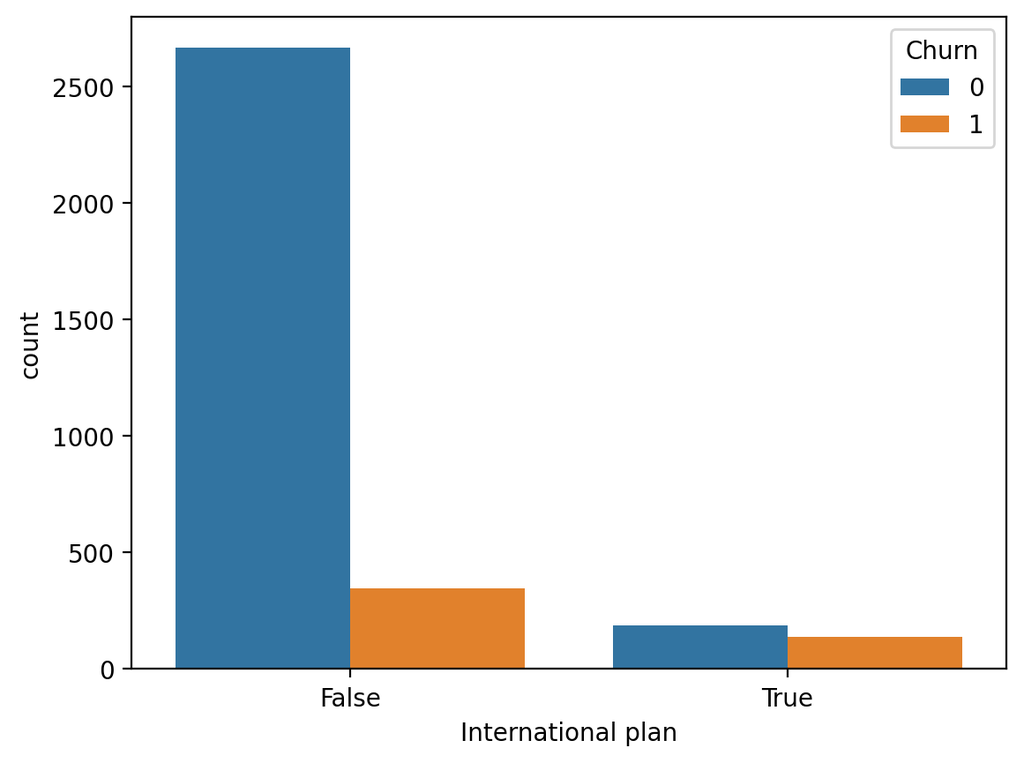

```python
sns.countplot(x="International plan", hue="Churn", data=df);
```

## Univariate visualization

*Univariate* analysis looks at one feature at a time. When we analyze a feature independently, we are usually mostly interested in the *distribution of its values* and ignore other features in the dataset.

Create histograms to visualize the distribution of values for the features "Total day minutes" and "Total intl calls"?

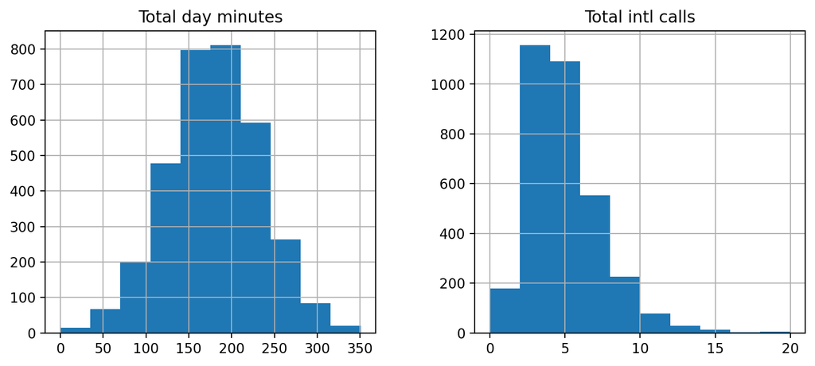

```python
features = ["Total day minutes", "Total intl calls"]
df[features].hist(figsize=(10, 4));
```

Create density plots to visualize the distribution of values for the features "Total day minutes" and "Total intl calls"?

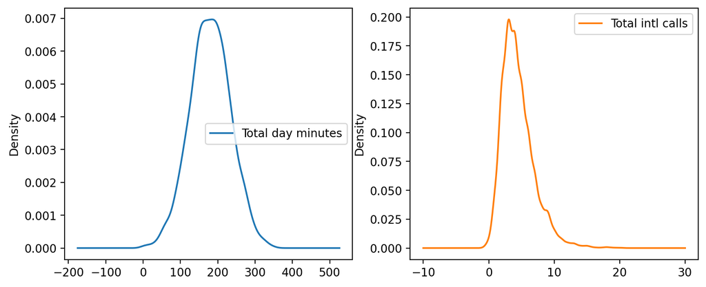

```python
df[features].plot(
    kind="density", subplots=True, layout=(1, 2), sharex=False, figsize=(10, 4)
);
```

Create a box plot to visualize the distribution of the "Total intl calls" feature

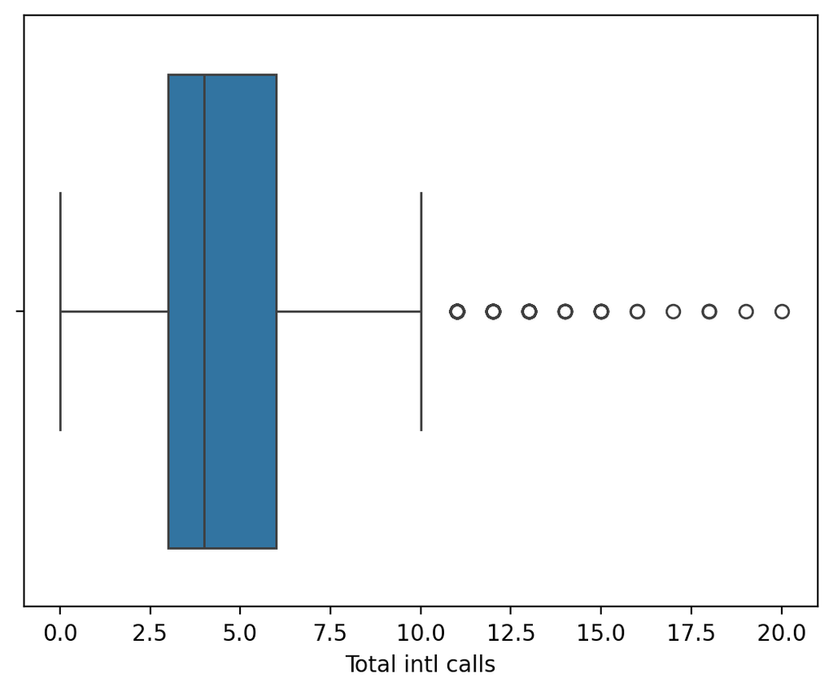

```python
sns.boxplot(x="Total intl calls", data=df);
```

Make a comparison between a box plot and a violin plot for visualizing the distribution of the "Total intl calls" feature.

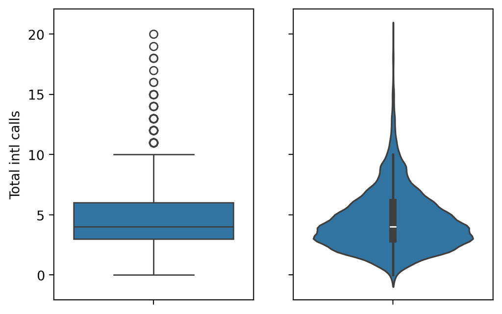

```python
_, axes = plt.subplots(1, 2, sharey=True, figsize=(6, 4))
sns.boxplot(data=df["Total intl calls"], ax=axes[0])
sns.violinplot(data=df["Total intl calls"], ax=axes[1]);
```

## Multivariate visualization

Create a correlation matrix to visualize the relationships among numerical variables in a DataFrame, and display it using a heatmap?

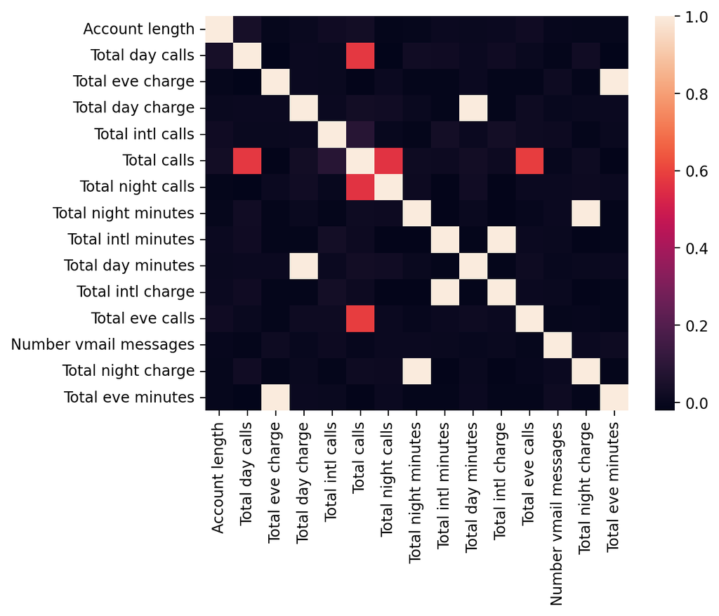

```python
# Drop non-numerical variables
numerical = list(
    set(df.columns)
    - set(
        [
            "State",
            "International plan",
            "Voice mail plan",
            "Area code",
            "Churn",
            "Customer service calls",
        ]
    )
)

# Calculate and plot
corr_matrix = df[numerical].corr()
sns.heatmap(corr_matrix);
```

##### Scatter plot

Create a scatter plot to visualize the relationship between two numerical variables, such as "Total day minutes" and "Total night minutes,"?

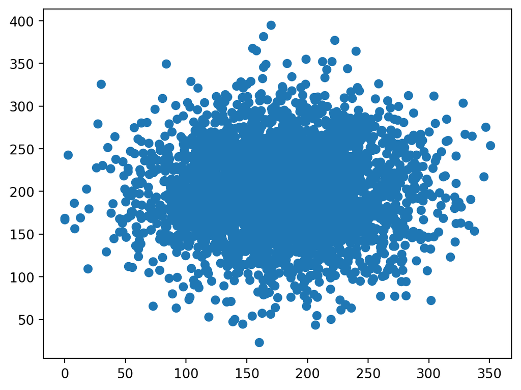

```python
plt.scatter(df["Total day minutes"], df["Total night minutes"]);
```

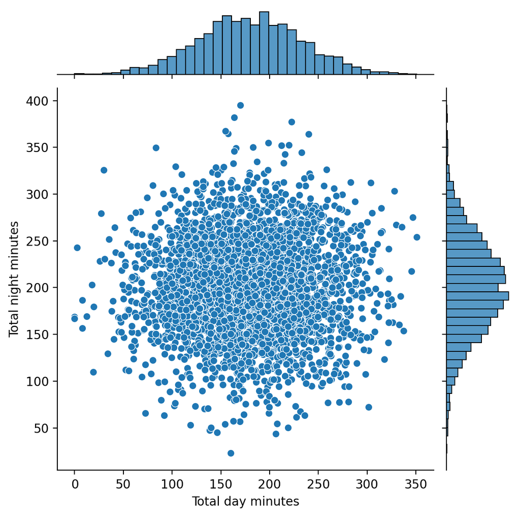

```python
sns.jointplot(x="Total day minutes", y="Total night minutes", data=df, kind="scatter");
```

Create a count plot to visualize the distribution of the "Customer service calls" variable, with different colors representing the "Churn" categories.

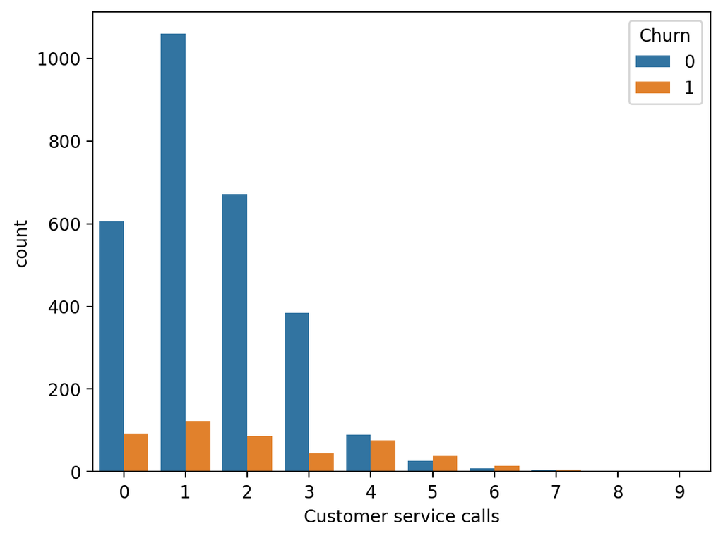

```python
sns.countplot(x="Customer service calls", hue="Churn", data=df);
```

# Data Transformation

```python
from sklearn.preprocessing import StandardScaler
```

# Splitting a Dataset into Train & Test Set

How can you split a dataset into training and testing sets, with 25% of the data reserved for testing?

```python
from sklearn import tree
from sklearn.model_selection import train_test_split
from sklearn.tree import DecisionTreeRegressor
```

```python
columns=['State', 'Account length', 'Area code', 'International plan',
       'Voice mail plan', 'Number vmail messages', 'Total day minutes',
       'Total day calls', 'Total day charge', 'Total eve minutes',
       'Total eve calls', 'Total eve charge', 'Total night minutes',
       'Total night calls', 'Total night charge', 'Total intl minutes',
       'Total intl calls', 'Total intl charge', 'Customer service calls',
       'Churn']
df = df.loc[:, columns]
features = ['State', 'Account length', 'Area code', 'International plan',
       'Voice mail plan', 'Number vmail messages', 'Total day minutes',
       'Total day calls', 'Total day charge', 'Total eve minutes',
       'Total eve calls', 'Total eve charge', 'Total night minutes',
       'Total night calls', 'Total night charge', 'Total intl minutes',
       'Total intl calls', 'Total intl charge']
X = df.loc[:, features]
y = df.loc[:, ['Customer service calls']]
X_train, X_test, y_train, y_test = train_test_split(X, y, random_state=0, train_size = .75)
```

# Classification using Machine Learning

```python
from sklearn.tree import DecisionTreeClassifier
```

**Some additional questions**

1. If you will be asked to choose a single feature for classification which one you will choose.

Justify with analysis.

Logistic Regression which is a binary classification algorithm to stepover the practical problems that hold back Linear Regression for classification. It deals with discrete values unlike Linear Regression which deals with continous values and also maintains the value of the threshold even when new data points are added.It is a data analysis technique that uses mathematics to find the relationships between two data factors. It then uses this relationship to predict the value of one of those factors based on the other. The prediction usually has a finite number of outcomes, like yes or no.

2. If you will be asked to choose two features for classification which two you will choose.

Justify with analysis.

Decision Tree as it is a predictive algorithm for classification. Some other features that make it so popular are: Extremely fast classification for unknown records. Disregards features that are of little or no importance in prediction.